# marquee

```r
library(marquee)
library(grid)
library(ggplot2)
```

This document will get you up to speed on using marquee for rich text formatting in R graphics. Marquee is collectively a markdown dialect, a parser for the dialect and a grid renderer for text written in the dialect. The package aims to fill the same use cases as [gridtext](https://wilkelab.org/gridtext/) and [ggtext](https://wilkelab.org/ggtext/) by Claus Wilke, but works in a very different and more low-level way.

## Requirements

Before we start we should note that marquee has been build for the future. What I mean by this is that it is based on a slew of new features in the R graphics engine putting very hard requirements on what R version it can be used with *and* which graphics devices it works with. If, for some reason, your setup cannot accommodate these needs you can perhaps get some of the way using [gridtext](https://wilkelab.org/gridtext/)/[ggtext](https://wilkelab.org/ggtext/). The nuisance of this will likely diminish or completely disappear with time.

## An example

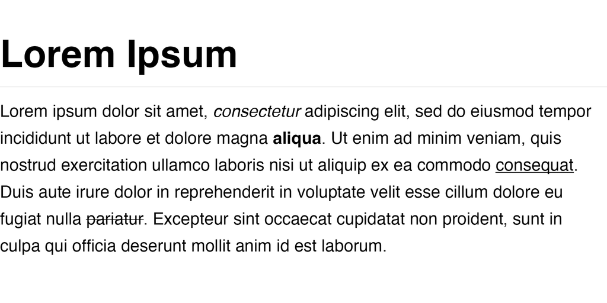

```r
md_text <-
"# Lorem Ipsum
Lorem ipsum dolor sit amet, *consectetur* adipiscing elit, sed do eiusmod tempor incididunt ut
labore et dolore magna **aliqua**. Ut enim ad minim veniam, quis nostrud exercitation ullamco
laboris nisi ut aliquip ex ea commodo _consequat_. Duis aute irure dolor in reprehenderit in
voluptate velit esse cillum dolore eu fugiat nulla ~pariatur~. Excepteur sint occaecat
cupidatat non proident, sunt in culpa qui officia deserunt mollit anim id est laborum."

grob <- marquee_grob(md_text, classic_style())

grid.draw(grob)
```

From this small example you can see that markdown behaves as you’d expect. We have emphasis, strong, underline, and strikethrough, and stuff like headings etc. In fact, the full markdown (CommonMark) spec is supported and will behave as you’d expect.

Besides the standard grob arguments you’d expect, `marquee_grob()` takes two main arguments as you can see above. The text, which can be a character vector with multiple separate markdown strings, and a style specification, which again can be a vector of styles or a single style to format everything alike. Marquee ships with `classic_style()` which is designed to mimic the look of standard HTML rendered markdown. The function itself allows you to modify the final style, and you could also modify it after construction to create a completely new style:

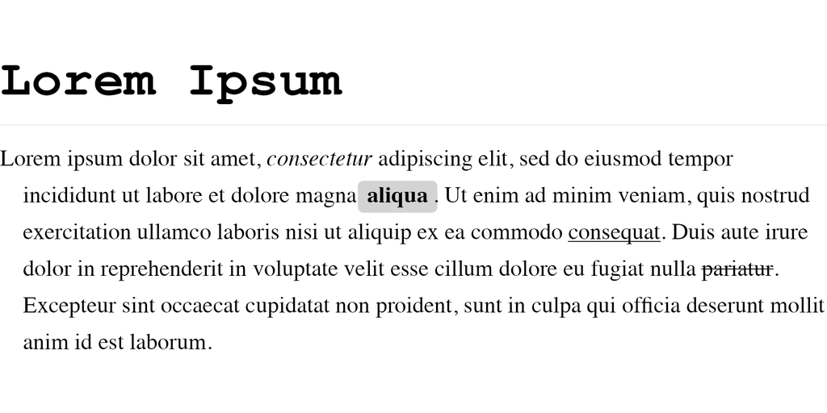

```r
new_style <- classic_style(body_font = "serif", header_font = "mono", hanging = em(1))

new_style <- modify_style(
  new_style,
  "str",
  background = "lightgrey",
  border_radius = 3,
  padding = trbl(em(0.2))
)

grid.draw(
  marquee_grob(md_text, new_style)
)
```

Besides standard markdown, marquee also allows you to create custom span classes. These span classes can be styled to anything, but marquee contains a nifty feature where, if the class matches a recognized color name or hex-code, it will be automatically coloured.

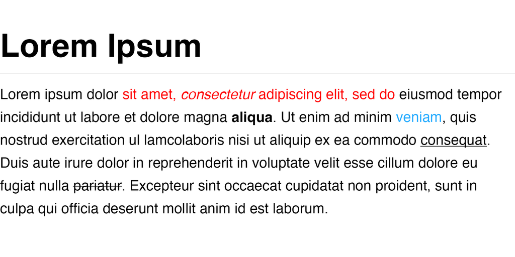

```r
md_text_custom <-
"# Lorem Ipsum
Lorem ipsum dolor {.red sit amet, *consectetur* adipiscing elit, sed do} eiusmod tempor
incididunt ut labore et dolore magna **aliqua**. Ut enim ad minim {#2af veniam}, quis nostrud
exercitation ul lamcolaboris nisi ut aliquip ex ea commodo _consequat_. Duis aute irure dolor
in reprehenderit in voluptate velit esse cillum dolore eu fugiat nulla ~pariatur~. Excepteur
sint occaecat cupidatat non proident, sunt in culpa qui officia deserunt mollit anim id est
laborum."

grid.draw(
  marquee_grob(md_text_custom, classic_style())
)
```

If you provide a styling for the custom class it takes precedence over any matching color name

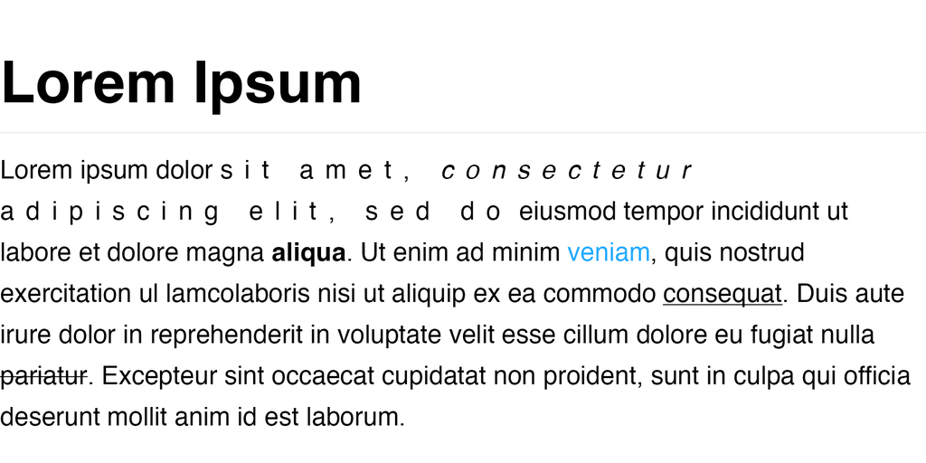

```r
grid.draw(
  marquee_grob(md_text_custom, modify_style(classic_style(), "red", tracking = 400))
)
```

## Use in ggplot2

Recognizing that most people doesn’t make visualizations directly with grid, marquee also contains the infrastructure to use markdown inside ggplot2 plots. It is expected that these functions will eventually move to ggplot2 proper, but while the package is stress tested they will stay here.

### The marquee geom

One way to use marquee with ggplot2 is with `geom_marquee()`. It supersedes both `geom_text()` and `geom_label()` in its capabilities, and even if you don’t need to plot rich text, the styling of `geom_marquee()` is much more capable:

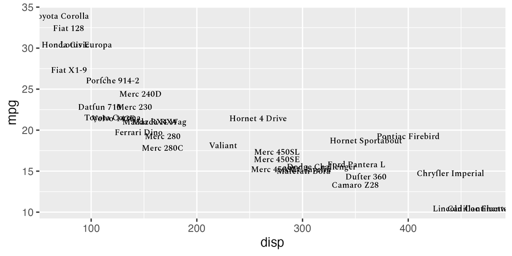

```r
fancy_font <- classic_style(
  weight = "semibold",
  features = systemfonts::font_feature(
    ligatures = c("standard", "discretionary"),
    letters = c("stylistic", "swash", "historical")
  )
)
ggplot(mtcars, aes(disp, mpg, label = rownames(mtcars))) +
  geom_marquee(style = fancy_font, size = 2.5, family = "spectral") # You may not have this font
```

However, the main use will probably be to mix in italicized, bold, or colored fonts in labels, which marquee makes very easy

```r
cars <- sub("(\\w+)", "{.red ***\\1***}", rownames(mtcars))
cars
```

```
#>  [1] "{.red ***Mazda***} RX4"           "{.red ***Mazda***} RX4 Wag"
#>  [3] "{.red ***Datsun***} 710"          "{.red ***Hornet***} 4 Drive"
#>  [5] "{.red ***Hornet***} Sportabout"   "{.red ***Valiant***}"
#>  [7] "{.red ***Duster***} 360"          "{.red ***Merc***} 240D"
#>  [9] "{.red ***Merc***} 230"            "{.red ***Merc***} 280"
#> [11] "{.red ***Merc***} 280C"           "{.red ***Merc***} 450SE"
#> [13] "{.red ***Merc***} 450SL"          "{.red ***Merc***} 450SLC"
#> [15] "{.red ***Cadillac***} Fleetwood"  "{.red ***Lincoln***} Continental"
#> [17] "{.red ***Chrysler***} Imperial"   "{.red ***Fiat***} 128"
#> [19] "{.red ***Honda***} Civic"         "{.red ***Toyota***} Corolla"
#> [21] "{.red ***Toyota***} Corona"       "{.red ***Dodge***} Challenger"
#> [23] "{.red ***AMC***} Javelin"         "{.red ***Camaro***} Z28"
#> [25] "{.red ***Pontiac***} Firebird"    "{.red ***Fiat***} X1-9"
#> [27] "{.red ***Porsche***} 914-2"       "{.red ***Lotus***} Europa"
#> [29] "{.red ***Ford***} Pantera L"      "{.red ***Ferrari***} Dino"
#> [31] "{.red ***Maserati***} Bora"       "{.red ***Volvo***} 142E"
```

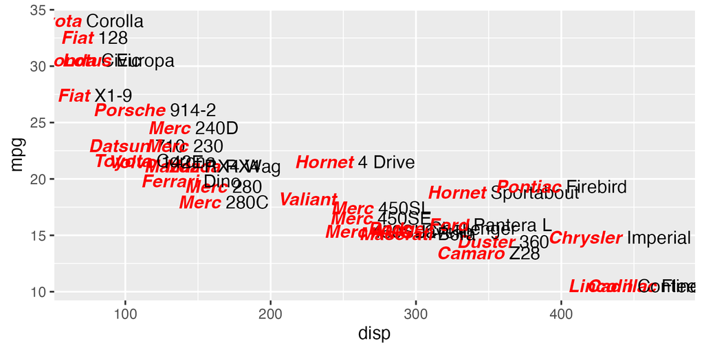

```r
ggplot(mtcars) + aes(disp, mpg, label = cars) +
  geom_marquee()
```

Another use of the geom, where rich text may come more into play, is in annotations. Let’s make a textbox style and add some lorem ipsum to our plot

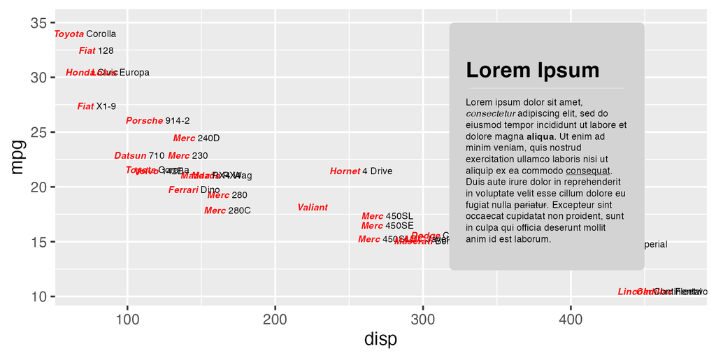

```r
text_box_style <- modify_style(
  classic_style(base_size = 2),
  "body",
  padding = skip_inherit(trbl(10)),
  border_radius = 3
)

ggplot(mtcars) + aes(disp, mpg, label = cars) +
  geom_marquee(size = 2) +
  annotate(GeomMarquee,
    label = md_text,
    x = 450,
    y = 35,
    style = text_box_style,
    size = 2,
    fill = "lightgrey",
    width = 0.3,
    hjust = "right",
    vjust = "top"
  )
```

### The marquee element

Rich text in plotted text is probably limited in use, but when you need it you really need it. Different from this is formatting of the text that surrounds the plot. Here you tend to treat the text as rich text and would want full control of the styling. Enter `element_marquee()`, a drop-in substitute for `element_text()` which will format and style any non-plotting text.

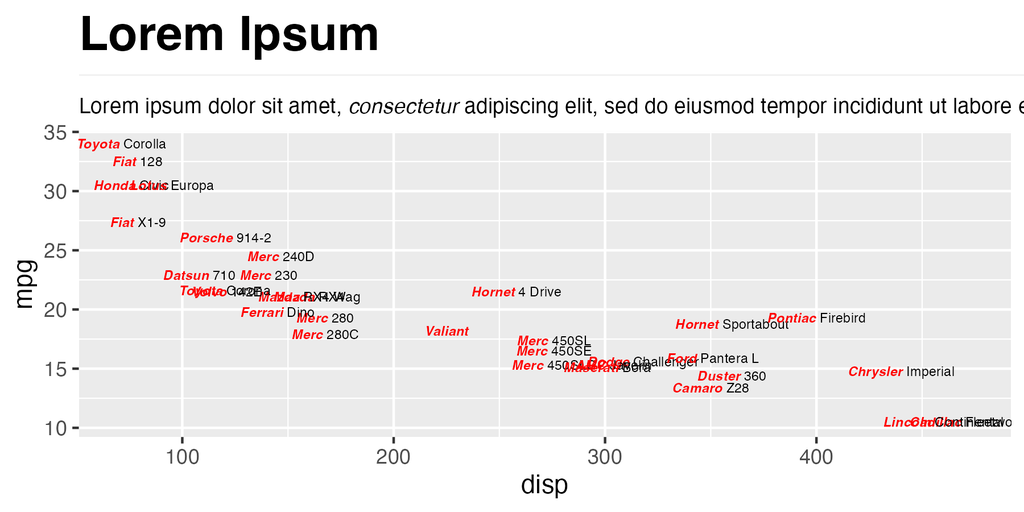

```r
ggplot(mtcars) + aes(disp, mpg, label = cars) +
  geom_marquee(size = 2) +
  ggtitle(md_text) +
  theme(plot.title = element_marquee(size = 9))
```

As can be seen, the defaults will let the text run for as long as it needs without doing any text wrapping. This is because it makes alignment behave in the same way as `element_text()`. However, if you have a lot of text like we do above, you certainly want to turn on that feature. You do that by setting a width. `1` is equivalent to the width of the area the element occupies so that is a natural value here, but you can set it to any `grid::unit()` value you wish.

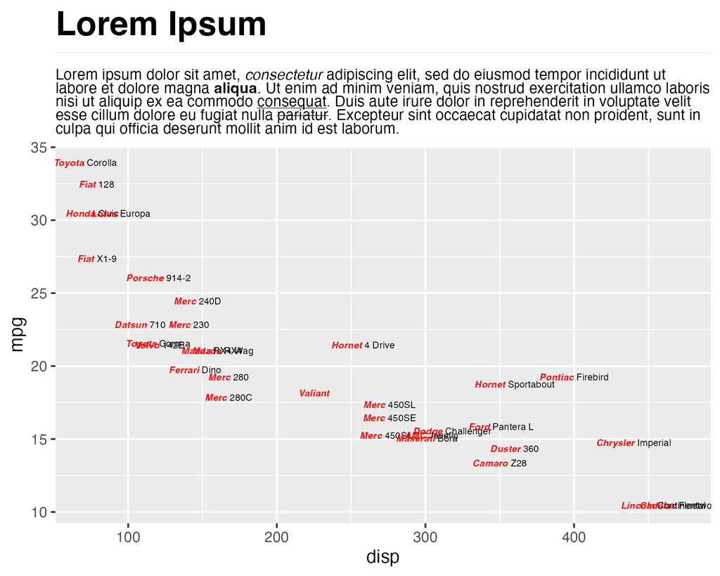

```r
ggplot(mtcars) + aes(disp, mpg, label = cars) +
  geom_marquee(size = 2) +
  ggtitle(md_text) +
  theme(plot.title = element_marquee(size = 9, width = 1))
```

## A bit about images

Markdown famously supports images through the `![]()` syntax. So does marquee of course (which means you can put images everywhere in ggplot2 if you wish). Currently, there is support for PNG, JPEG, and SVG, with the latter being responsive to resizing etc. The images can reside online or on your computer — it all should “just work”. If an image is placed inline it is sized to fit the height of that line and adjusting the width to keep the correct aspect ratio. If an image is placed by itself, it expands to fill the provided width, width the height being calculated to match the aspect ratio of the image.

[figure not shown]

```r
md_text_fig <-
"# Lorem Ipsum ![](https://cran.r-project.org/Rlogo.svg)
Lorem ipsum dolor {.red sit amet, *consectetur* adipiscing elit, sed do} eiusmod tempor
incididunt ut labore et dolore magna **aliqua**. Ut enim ad minim {#2af veniam}, quis nostrud
exercitation ul lamcolaboris nisi ut aliquip ex ea commodo _consequat_. Duis aute irure dolor
in reprehenderit in voluptate velit esse cillum dolore eu fugiat nulla ~pariatur~. Excepteur
sint occaecat cupidatat non proident, sunt in culpa qui officia deserunt mollit anim id est
laborum."

grid.draw(marquee_grob(md_text_fig, classic_style()))
```

Compare that to

[figure not shown]

```r
md_text_fig2 <-
"# Lorem Ipsum

![](https://cran.r-project.org/Rlogo.svg)

Lorem ipsum dolor {.red sit amet, *consectetur* adipiscing elit, sed do} eiusmod tempor
incididunt ut labore et dolore magna **aliqua**. Ut enim ad minim {#2af veniam}, quis nostrud
exercitation ul lamcolaboris nisi ut aliquip ex ea commodo _consequat_. Duis aute irure dolor
in reprehenderit in voluptate velit esse cillum dolore eu fugiat nulla ~pariatur~. Excepteur
sint occaecat cupidatat non proident, sunt in culpa qui officia deserunt mollit anim id est
laborum."

grid.draw(marquee_grob(md_text_fig2, classic_style()))
```

However, marquee has a pretty unique trick up it’s sleeve compared to other markdown formats. It doesn’t just accept paths to images — it also accepts R graphic objects (currently grid grobs, ggplot2 plots and patchwork plots). It all works as you’d expect:

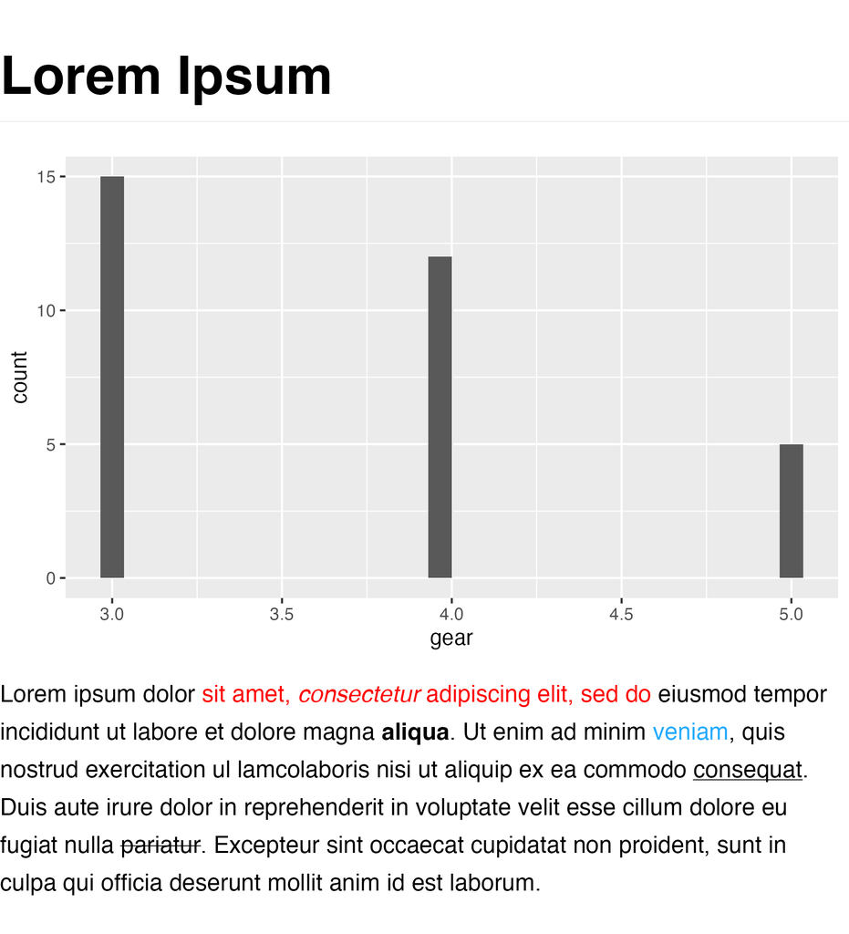

```r
p <- ggplot(mtcars) +
  geom_histogram(aes(x = gear))


md_text_plot <-
"# Lorem Ipsum

![](p)

Lorem ipsum dolor {.red sit amet, *consectetur* adipiscing elit, sed do} eiusmod tempor
incididunt ut labore et dolore magna **aliqua**. Ut enim ad minim {#2af veniam}, quis nostrud
exercitation ul lamcolaboris nisi ut aliquip ex ea commodo _consequat_. Duis aute irure dolor
in reprehenderit in voluptate velit esse cillum dolore eu fugiat nulla ~pariatur~. Excepteur
sint occaecat cupidatat non proident, sunt in culpa qui officia deserunt mollit anim id est
laborum."

grid.draw(marquee_grob(md_text_plot, classic_style()))
```

## A bit about tables

The table markdown syntax is not supported in marquee. However, you can still include tables in marquee, and with much more styling support than standard markdown table syntax provide. This magic is an extension of what was talked about above. More to the point, gt table objects are recognized as valid objects in the image tag path and can thus be included directly in the output. We show the power here with a table specification taken from the [gt introduction](https://gt.rstudio.com/articles/gt.html):

```r
library(gt)
airquality_m <- airquality[1:10, ]
airquality_m$Year <- 1973L
table <- gt(airquality_m)
table <- tab_header(table,
  title = "New York Air Quality Measurements",
  subtitle = "Daily measurements in New York City (May 1-10, 1973)"
)
table <- tab_spanner(table,
  label = "Time",
  columns = c(Year, Month, Day)
)
table <- tab_spanner(table,
  label = "Measurement",
  columns = c(Ozone, Solar.R, Wind, Temp)
)
```

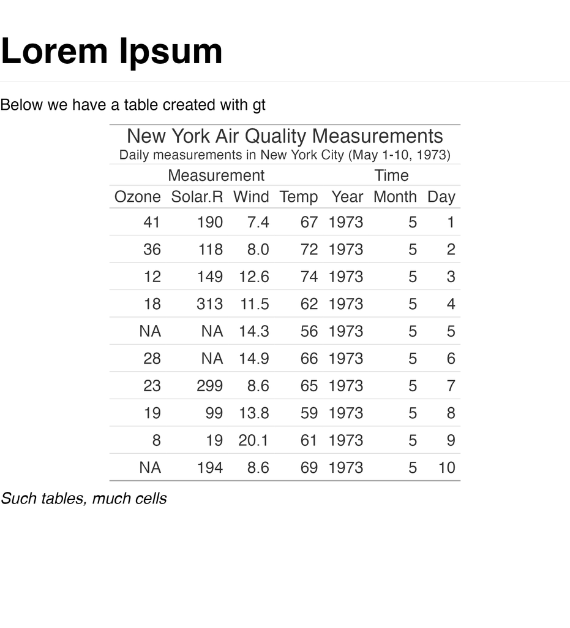

```r
md_text_table <-
"# Lorem Ipsum
Below we have a table created with gt

![](table)

*Such tables, much cells*"

grid.draw(marquee_grob(md_text_table, classic_style()))
```

The support is still somewhat experimental as gt-to-grob conversion is getting build out. Some gt features rely on HTML formatting still and will end up looking weird, but standard table inclusion works as expected.

## Wrapping up

This should give you enough of an overview to get started. The Marquee Style and Marquee Syntax vignettes provides a bit more detail on their respective areas if you need to dive deeper.